# exploratory_personality_with_MI

### Neuroticism

First, relationship between neuroticism & consumer intentions for each norm condition:

```r
emtrends(mod_mice, ~norm_condition, var = "neuroticism_center", adjust = "none")
```

```
##  norm_condition   neuroticism_center.trend    SE  df lower.CL upper.CL
##  control_norm                       0.1922 0.114 948 -0.03210    0.416
##  descriptive_norm                   0.0419 0.120 948 -0.19373    0.277
##  convention_norm                    0.3174 0.116 948  0.08997    0.545
##  social_norm                        0.0465 0.127 948 -0.20206    0.295
##  moral_norm                         0.2154 0.113 948 -0.00551    0.436
##
## Results are averaged over the levels of: framing_condition, Gender
## Confidence level used: 0.95
```

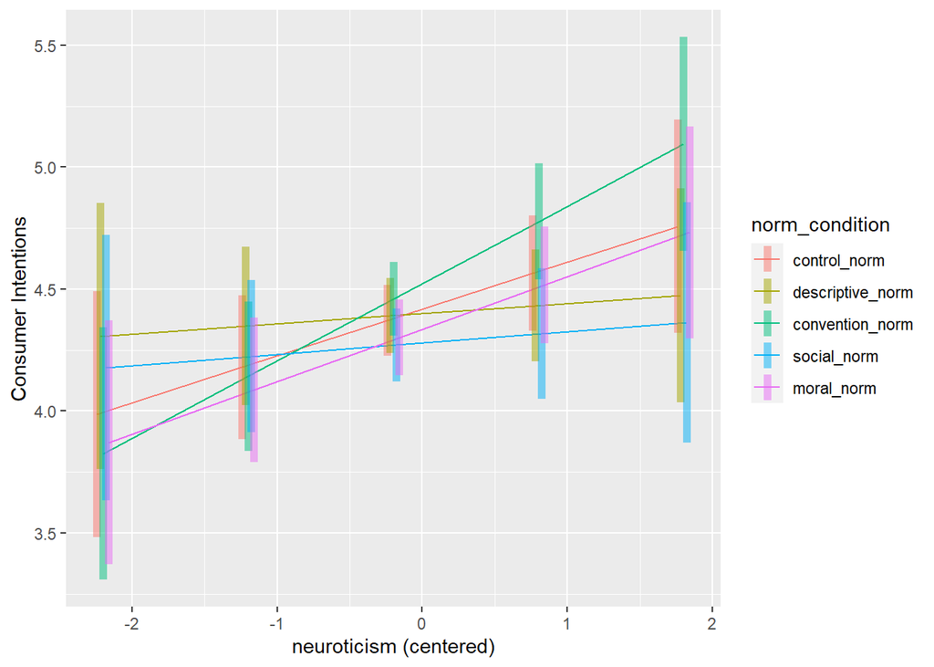

```r
# On a single graph
at_list <- list(neuroticism_center = seq(-2.2, 2.1, by = 1))

emmip(mod_mice, norm_condition ~ neuroticism_center, at = at_list, CIs = TRUE, xlab = "neuroticism (centered)", ylab = "Consumer Intentions")
```

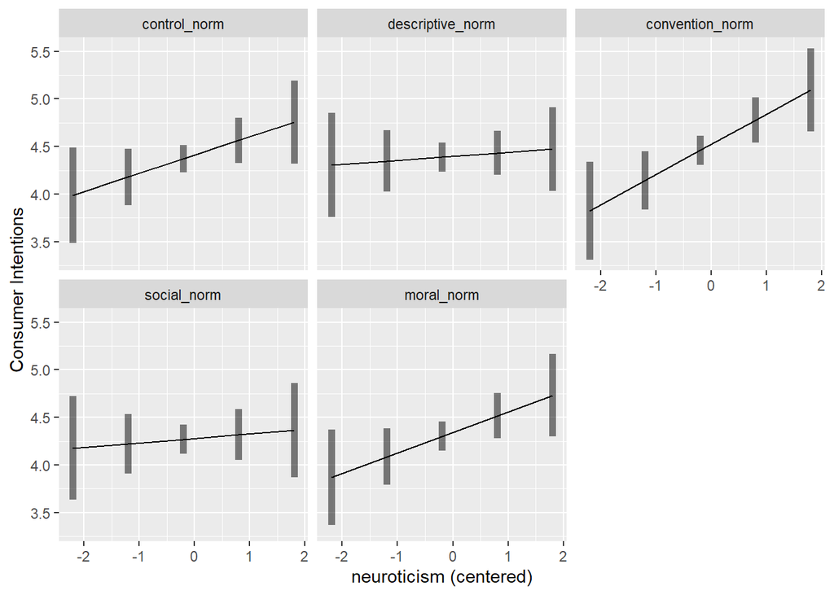

```r
# Separate graph for each norm
emmip(mod_mice, ~ neuroticism_center | norm_condition, at = at_list, CIs = TRUE, xlab = "neuroticism (centered)", ylab = "Consumer Intentions")
```

Is the slope of the relationship between neuroticism & consumer intentions stronger in any one of the norm conditions compared to the others?

```r
emtrends(mod_mice, pairwise~norm_condition, var = "neuroticism_center", adjust = "none")
```

```
## $emtrends
##  norm_condition   neuroticism_center.trend    SE  df lower.CL upper.CL
##  control_norm                       0.1922 0.114 948 -0.03210    0.416
##  descriptive_norm                   0.0419 0.120 948 -0.19373    0.277
##  convention_norm                    0.3174 0.116 948  0.08997    0.545
##  social_norm                        0.0465 0.127 948 -0.20206    0.295
##  moral_norm                         0.2154 0.113 948 -0.00551    0.436
##
## Results are averaged over the levels of: framing_condition, Gender
## Confidence level used: 0.95
##
## $contrasts
##  contrast                           estimate    SE  df t.ratio p.value
##  control_norm - descriptive_norm     0.15031 0.158 948   0.949  0.3429
##  control_norm - convention_norm     -0.12519 0.156 948  -0.803  0.4224
##  control_norm - social_norm          0.14572 0.164 948   0.891  0.3731
##  control_norm - moral_norm          -0.02319 0.153 948  -0.152  0.8793
##  descriptive_norm - convention_norm -0.27549 0.160 948  -1.721  0.0856
##  descriptive_norm - social_norm     -0.00459 0.168 948  -0.027  0.9782
##  descriptive_norm - moral_norm      -0.17349 0.157 948  -1.104  0.2700
##  convention_norm - social_norm       0.27090 0.166 948   1.636  0.1021
##  convention_norm - moral_norm        0.10200 0.155 948   0.658  0.5106
##  social_norm - moral_norm           -0.16890 0.163 948  -1.038  0.2997
##
## Results are averaged over the levels of: framing_condition, Gender
```

Second, relationship between neuroticism & consumer intentions for each framing condition:

```r
emtrends(mod_mice, ~framing_condition, var = "neuroticism_center", adjust = "none")
```

```
##  framing_condition neuroticism_center.trend     SE  df lower.CL upper.CL
##  control_framing                      0.169 0.0869 948 -0.00153    0.339
##  pro_env_framing                      0.157 0.0959 948 -0.03101    0.346
##  self_enh_framing                     0.162 0.0981 948 -0.03068    0.354
##
## Results are averaged over the levels of: norm_condition, Gender
## Confidence level used: 0.95
```

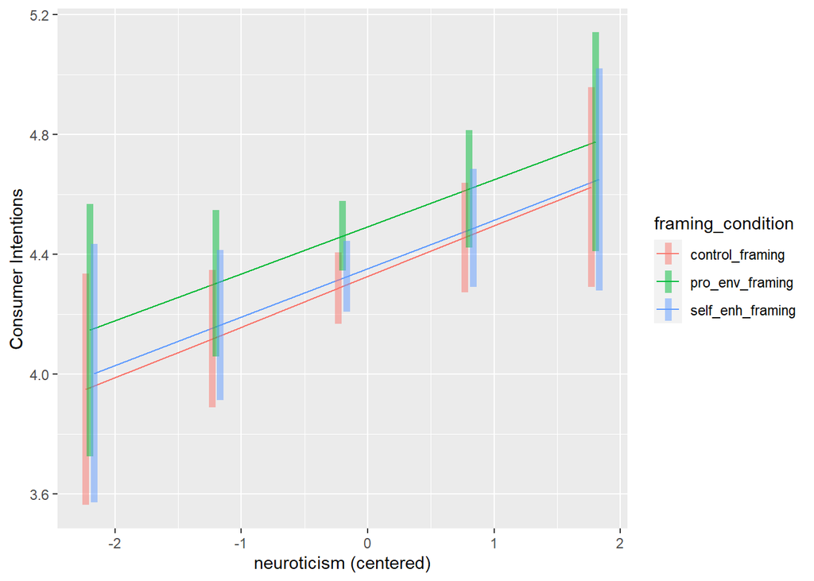

```r
# On a single graph
at_list <- list(neuroticism_center = seq(-2.2, 2.1, by = 1))

emmip(mod_mice, framing_condition ~ neuroticism_center, at = at_list, CIs = TRUE, xlab = "neuroticism (centered)", ylab = "Consumer Intentions")
```

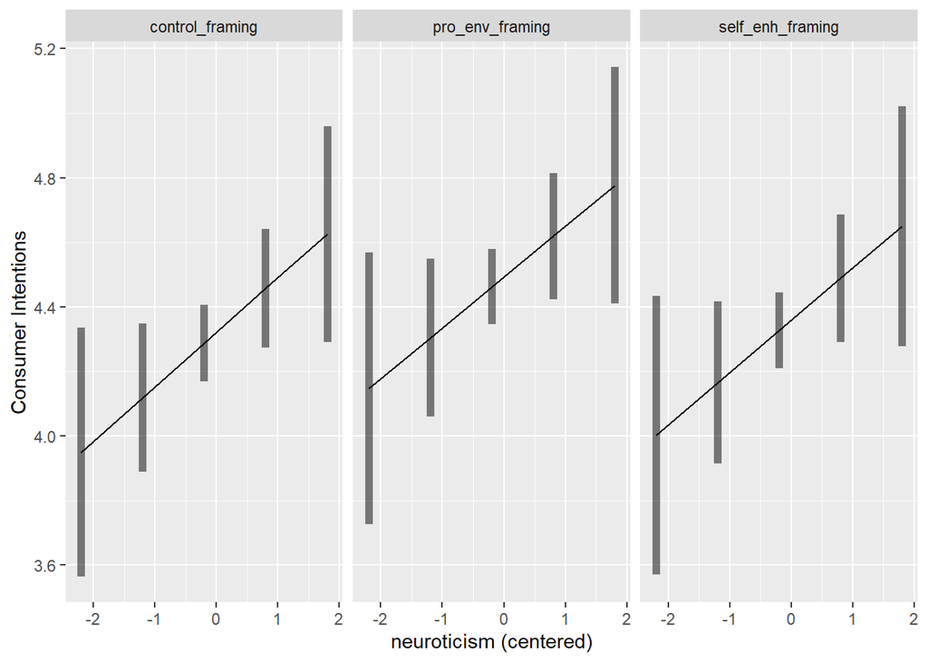

```r
# Separate graph for each norm
emmip(mod_mice, ~ neuroticism_center | framing_condition, at = at_list, CIs = TRUE, xlab = "neuroticism (centered)", ylab = "Consumer Intentions")
```

Is the slope of the relationship between neuroticism & consumer intentions stronger in any one of the framing conditions compared to the others?

```r
emtrends(mod_mice, pairwise~framing_condition, var = "neuroticism_center", adjust = "none")
```

```
## $emtrends
##  framing_condition neuroticism_center.trend     SE  df lower.CL upper.CL
##  control_framing                      0.169 0.0869 948 -0.00153    0.339
##  pro_env_framing                      0.157 0.0959 948 -0.03101    0.346
##  self_enh_framing                     0.162 0.0981 948 -0.03068    0.354
##
## Results are averaged over the levels of: norm_condition, Gender
## Confidence level used: 0.95
##
## $contrasts
##  contrast                           estimate    SE  df t.ratio p.value
##  control_framing - pro_env_framing   0.01167 0.121 948   0.096  0.9233
##  control_framing - self_enh_framing  0.00716 0.122 948   0.059  0.9532
##  pro_env_framing - self_enh_framing -0.00451 0.128 948  -0.035  0.9718
##
## Results are averaged over the levels of: norm_condition, Gender
```

Third, interaction between neuroticism, framing, & norm condition:

```r
emtrends(mod_mice, ~norm_condition | framing_condition, var = "neuroticism_center", adjust = "none")
```

```
## framing_condition = control_framing:
##  norm_condition   neuroticism_center.trend    SE  df lower.CL upper.CL
##  control_norm                       0.3845 0.173 948   0.0448    0.724
##  descriptive_norm                  -0.0949 0.201 948  -0.4896    0.300
##  convention_norm                    0.4112 0.189 948   0.0396    0.783
##  social_norm                        0.3014 0.164 948  -0.0212    0.624
##  moral_norm                        -0.1576 0.191 948  -0.5323    0.217
##
## framing_condition = pro_env_framing:
##  norm_condition   neuroticism_center.trend    SE  df lower.CL upper.CL
##  control_norm                       0.0495 0.187 948  -0.3180    0.417
##  descriptive_norm                  -0.0258 0.214 948  -0.4457    0.394
##  convention_norm                    0.4220 0.191 948   0.0466    0.798
##  social_norm                       -0.0104 0.233 948  -0.4671    0.446
##  moral_norm                         0.3510 0.190 948  -0.0209    0.723
##
## framing_condition = self_enh_framing:
##  norm_condition   neuroticism_center.trend    SE  df lower.CL upper.CL
##  control_norm                       0.1425 0.213 948  -0.2754    0.561
##  descriptive_norm                   0.2463 0.187 948  -0.1211    0.614
##  convention_norm                    0.1189 0.207 948  -0.2876    0.525
##  social_norm                       -0.1516 0.238 948  -0.6194    0.316
##  moral_norm                         0.4527 0.185 948   0.0900    0.815
##
## Results are averaged over the levels of: Gender
## Confidence level used: 0.95
```

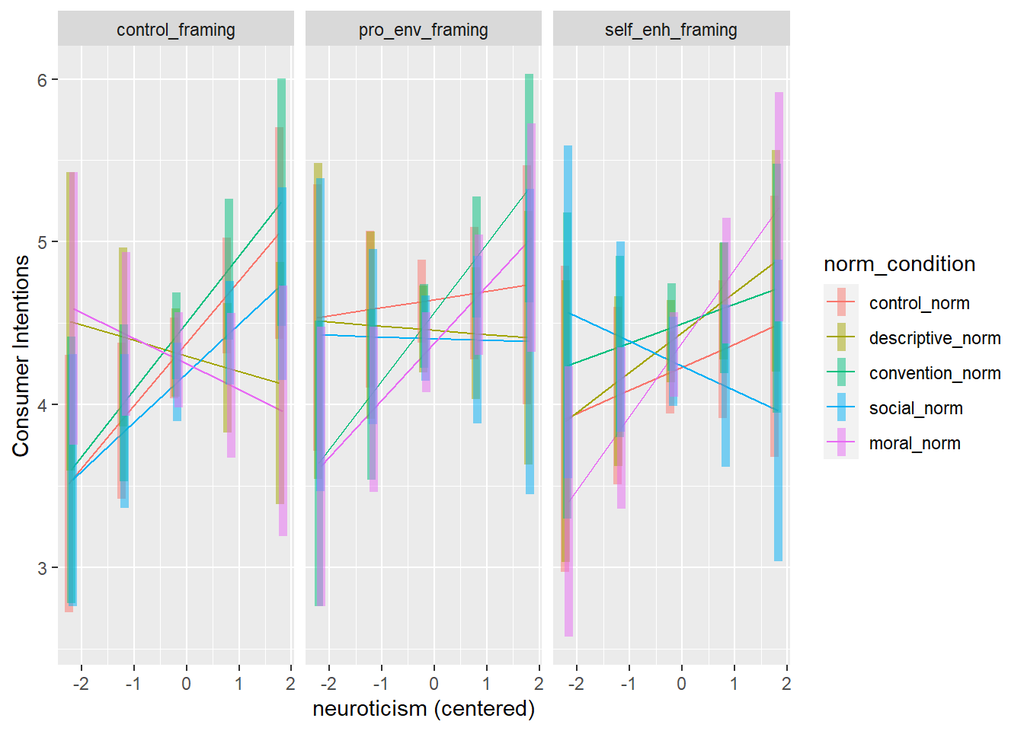

```r
# Separate graph for each framing condition
at_list <- list(neuroticism_center = seq(-2.2, 2.1, by = 1))

emmip(mod_mice, norm_condition ~ neuroticism_center | framing_condition, at = at_list, CIs = TRUE, xlab = "neuroticism (centered)", ylab = "Consumer Intentions")
```

### Honesty

First, relationship between honesty & consumer intentions for each norm condition:

```r
emtrends(mod_mice, ~norm_condition, var = "honesty_center", adjust = "none")
```

```
##  norm_condition   honesty_center.trend    SE  df lower.CL upper.CL
##  control_norm                   0.0130 0.120 948   -0.222   0.2480
##  descriptive_norm              -0.1860 0.123 948   -0.427   0.0553
##  convention_norm               -0.3318 0.120 948   -0.567  -0.0970
##  social_norm                   -0.0613 0.117 948   -0.291   0.1679
##  moral_norm                    -0.0511 0.128 948   -0.303   0.2008
##
## Results are averaged over the levels of: framing_condition, Gender
## Confidence level used: 0.95
```

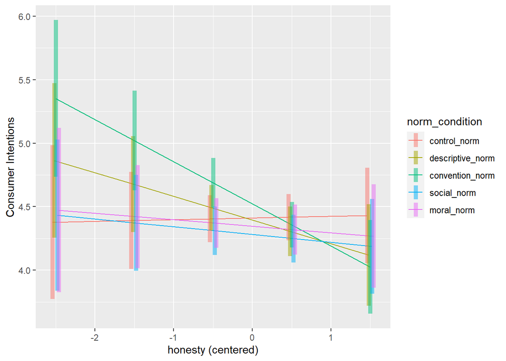

```r
# On a single graph
at_list <- list(honesty_center = seq(-2.5, 1.6, by = 1))

emmip(mod_mice, norm_condition ~ honesty_center, at = at_list, CIs = TRUE, xlab = "honesty (centered)", ylab = "Consumer Intentions")
```

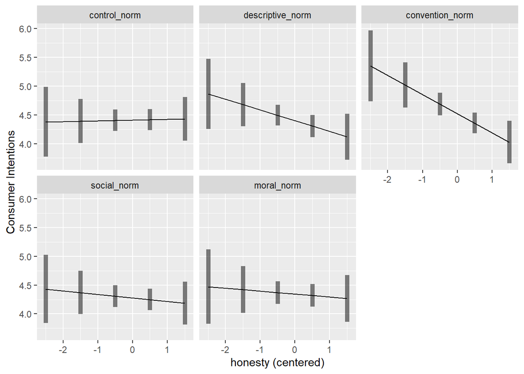

```r
# Separate graph for each norm
emmip(mod_mice, ~ honesty_center | norm_condition, at = at_list, CIs = TRUE, xlab = "honesty (centered)", ylab = "Consumer Intentions")
```

Is the slope of the relationship between honesty & consumer intentions stronger in any one of the norm conditions compared to the others?

```r
emtrends(mod_mice, pairwise~norm_condition, var = "honesty_center", adjust = "none")
```

```
## $emtrends
##  norm_condition   honesty_center.trend    SE  df lower.CL upper.CL
##  control_norm                   0.0130 0.120 948   -0.222   0.2480
##  descriptive_norm              -0.1860 0.123 948   -0.427   0.0553
##  convention_norm               -0.3318 0.120 948   -0.567  -0.0970
##  social_norm                   -0.0613 0.117 948   -0.291   0.1679
##  moral_norm                    -0.0511 0.128 948   -0.303   0.2008
##
## Results are averaged over the levels of: framing_condition, Gender
## Confidence level used: 0.95
##
## $contrasts
##  contrast                           estimate    SE  df t.ratio p.value
##  control_norm - descriptive_norm      0.1990 0.169 948   1.176  0.2399
##  control_norm - convention_norm       0.3448 0.168 948   2.054  0.0402
##  control_norm - social_norm           0.0743 0.165 948   0.451  0.6521
##  control_norm - moral_norm            0.0641 0.173 948   0.370  0.7113
##  descriptive_norm - convention_norm   0.1459 0.170 948   0.860  0.3901
##  descriptive_norm - social_norm      -0.1246 0.166 948  -0.749  0.4539
##  descriptive_norm - moral_norm       -0.1348 0.175 948  -0.771  0.4412
##  convention_norm - social_norm       -0.2705 0.165 948  -1.642  0.1009
##  convention_norm - moral_norm        -0.2807 0.174 948  -1.615  0.1065
##  social_norm - moral_norm            -0.0102 0.171 948  -0.060  0.9523
##
## Results are averaged over the levels of: framing_condition, Gender
```

Second, relationship between honesty & consumer intentions for each framing condition:

```r
emtrends(mod_mice, ~framing_condition, var = "honesty_center", adjust = "none")
```

```
##  framing_condition honesty_center.trend     SE  df lower.CL upper.CL
##  control_framing                 -0.039 0.0928 948   -0.221  0.14303
##  pro_env_framing                 -0.126 0.0923 948   -0.307  0.05561
##  self_enh_framing                -0.206 0.1000 948   -0.402 -0.00955
##
## Results are averaged over the levels of: norm_condition, Gender
## Confidence level used: 0.95
```

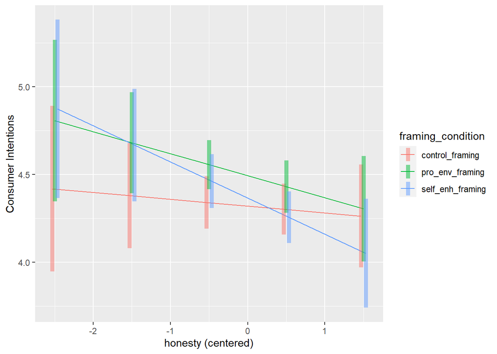

```r
# On a single graph
at_list <- list(honesty_center = seq(-2.5, 1.6, by = 1))

emmip(mod_mice, framing_condition ~ honesty_center, at = at_list, CIs = TRUE, xlab = "honesty (centered)", ylab = "Consumer Intentions")
```

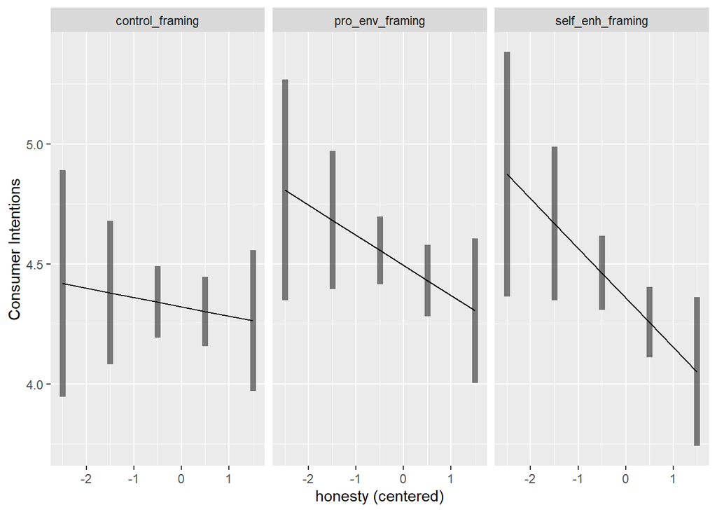

```r
# Separate graph for each norm
emmip(mod_mice, ~ honesty_center | framing_condition, at = at_list, CIs = TRUE, xlab = "honesty (centered)", ylab = "Consumer Intentions")
```

Is the slope of the relationship between honesty & consumer intentions stronger in any one of the framing conditions compared to the others?

```r
emtrends(mod_mice, pairwise~framing_condition, var = "honesty_center", adjust = "none")
```

```
## $emtrends
##  framing_condition honesty_center.trend     SE  df lower.CL upper.CL
##  control_framing                 -0.039 0.0928 948   -0.221  0.14303
##  pro_env_framing                 -0.126 0.0923 948   -0.307  0.05561
##  self_enh_framing                -0.206 0.1000 948   -0.402 -0.00955
##
## Results are averaged over the levels of: norm_condition, Gender
## Confidence level used: 0.95
##
## $contrasts
##  contrast                           estimate    SE  df t.ratio p.value
##  control_framing - pro_env_framing    0.0866 0.128 948   0.676  0.4993
##  control_framing - self_enh_framing   0.1668 0.134 948   1.248  0.2125
##  pro_env_framing - self_enh_framing   0.0802 0.133 948   0.605  0.5453
##
## Results are averaged over the levels of: norm_condition, Gender
```

Third, interaction between honesty, framing, & norm condition:

```r
emtrends(mod_mice, ~norm_condition | framing_condition, var = "honesty_center", adjust = "none")
```

```
## framing_condition = control_framing:
##  norm_condition   honesty_center.trend    SE  df lower.CL upper.CL
##  control_norm                 -0.00516 0.190 948   -0.378   0.3679
##  descriptive_norm             -0.08672 0.239 948   -0.556   0.3821
##  convention_norm              -0.06943 0.194 948   -0.449   0.3103
##  social_norm                  -0.08898 0.160 948   -0.403   0.2247
##  moral_norm                    0.05529 0.232 948   -0.399   0.5097
##
## framing_condition = pro_env_framing:
##  norm_condition   honesty_center.trend    SE  df lower.CL upper.CL
##  control_norm                 -0.03897 0.208 948   -0.446   0.3683
##  descriptive_norm             -0.40144 0.175 948   -0.744  -0.0588
##  convention_norm              -0.45381 0.196 948   -0.839  -0.0687
##  social_norm                   0.16768 0.223 948   -0.271   0.6060
##  moral_norm                    0.09849 0.199 948   -0.293   0.4898
##
## framing_condition = self_enh_framing:
##  norm_condition   honesty_center.trend    SE  df lower.CL upper.CL
##  control_norm                  0.08310 0.220 948   -0.348   0.5143
##  descriptive_norm             -0.06973 0.215 948   -0.492   0.3524
##  convention_norm              -0.47229 0.227 948   -0.917  -0.0272
##  social_norm                  -0.26275 0.207 948   -0.670   0.1441
##  moral_norm                   -0.30722 0.229 948   -0.757   0.1428
##
## Results are averaged over the levels of: Gender
## Confidence level used: 0.95
```

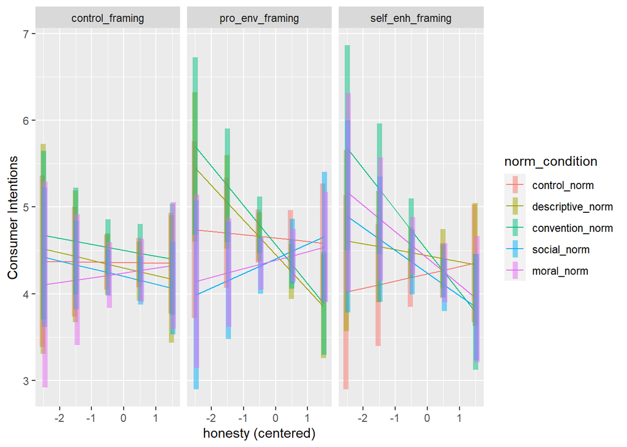

```r
# Separate graph for each framing condition
at_list <- list(honesty_center = seq(-2.5, 1.6, by = 1))

emmip(mod_mice, norm_condition ~ honesty_center | framing_condition, at = at_list, CIs = TRUE, xlab = "honesty (centered)", ylab = "Consumer Intentions")
```